# Assignment1_Group75

## Group ID

ADL Group 75

## Group Members

1. Ravindra Kumar Tholiya - 2023AA05124
2. Jahnavi Gali - 2023AA05684
3. Shivam Sahil - 2023AA05663
4. Chakshu - 2023aa05280

## Problem Statement

This assignment is about feature extraction via dimensionality reduction using variants of autoencoders. Use the CIFAR10 dataset provided in Keras, after conversion to gray-level images! Use randomly selected 70% of the dataset as training set and remaining 30% as the test set.

Task 1: Perform standard PCA with 70% of the training dataset and identify the eigenvectors associated with top eigenvalues with 95% total energy. With these, train a logistic regression classifier to classify the images into 10 classes. Draw the ROC curve for the test dataset. Repeat the same with randomized PCA and compare.

Task 2: Train a single layer autoencoder with linear activation function and appropriately mean and variance normalized input with constraint that encoder weight matrix and decoder weight matrix are transpose w,r,t, each other. Compare the eigenvectors obtained in step 1 with those obtained using the autoencoders. Explain your observations.

Task 3: Train an appropriate deep convolutional autoencoder with same dimension of latent space. Calculate the reconstruction error fand compare that with a single hidden layer autoencoder (with sigmoid activation at the autoencoder and linear at the decoder) for the test dataset. What will be the reconstruction error if the hidden nodes are distributed equally (approximately) among 3 hidden layers in a new 3 hidden layer autoencoder with sigmoid activation at the autoencoder and linear at the decoder final layer?

Task 4. Train a deep convolutional autoencoder with MNIST dataset and using extracted features train a MLP classifier with 7 outputs (7 segment LED display) that are representative of 10 digits. For example images of "0" will be classified as

1

1 1

1

1 1

1

7 will be "classified" as

1

0 1

0

0 1

0

Generate the confusion matrix for the corresponding test dataset.

Task 5: Upload both *.ipynb with all outputs embedded and corresponding *.html files.

Step 1: Use the CIFAR10 dataset provided in Keras. After conversion to gray-level images! Use randomly selected 70% of the dataset as training set and remaining 30% as the test set.

```python
# Perform necessary imports
import numpy as np
import matplotlib.pyplot as plt
from sklearn.model_selection import train_test_split
from sklearn.preprocessing import StandardScaler
from sklearn.decomposition import PCA
from sklearn.decomposition import TruncatedSVD
from sklearn.linear_model import LogisticRegression
from sklearn.metrics import roc_curve, auc
from tensorflow.keras.datasets import cifar10, mnist
from skimage.color import rgb2gray
import tensorflow as tf
from tensorflow.keras.models import Model
from tensorflow.keras.layers import Input, Dense, Lambda
from tensorflow.keras import backend as K, layers, models
from sklearn.metrics import confusion_matrix
from sklearn.metrics import accuracy_score, classification_report
import math
import random
```

# Task 1: Perform standard PCA with 70% of the training dataset and identify the eigenvectors associated with top eigenvalues with 95% total energy. With these, train a logistic regression classifier to classify the images into 10 classes. Draw the ROC curve for the test dataset. Repeat the same with randomized PCA and compare.

```
Downloading data from https://www.cs.toronto.edu/~kriz/cifar-10-python.tar.gz
170498071/170498071 ━━━━━━━━━━━━━━━━━━━━ 4s 0us/step
Training data shape: (42000, 32, 32)
Testing data shape: (18000, 32, 32)
```

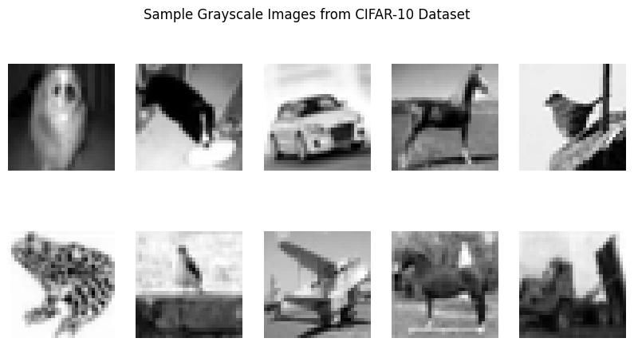

```python
# Step 1: Load CIFAR-10 dataset
(x_train, y_train), (x_test, y_test) = cifar10.load_data()

# Combine train and test data for splitting later
X = np.concatenate((x_train, x_test))
y = np.concatenate((y_train, y_test))

# Step 2: Convert images to grayscale
X_gray = np.array([rgb2gray(img) for img in X])

# Step 3: Normalize the dataset
X_gray = X_gray / 255.0

# Step 4: Split the data
X_train, X_test, y_train, y_test = train_test_split(X_gray, y, test_size=0.3, random_state=42)

# Verify data shapes
print("Training data shape:", X_train.shape)
print("Testing data shape:", X_test.shape)

# Display a few samples to verify grayscale conversion
plt.figure(figsize=(10, 5))
for i in range(10):
    plt.subplot(2, 5, i + 1)
    plt.imshow(X_train[i], cmap='gray')
    plt.axis('off')
plt.suptitle('Sample Grayscale Images from CIFAR-10 Dataset')
plt.show()
```

```
Original training data shape: (42000, 1024)
Reduced training data shape (PCA): (42000, 162)
```

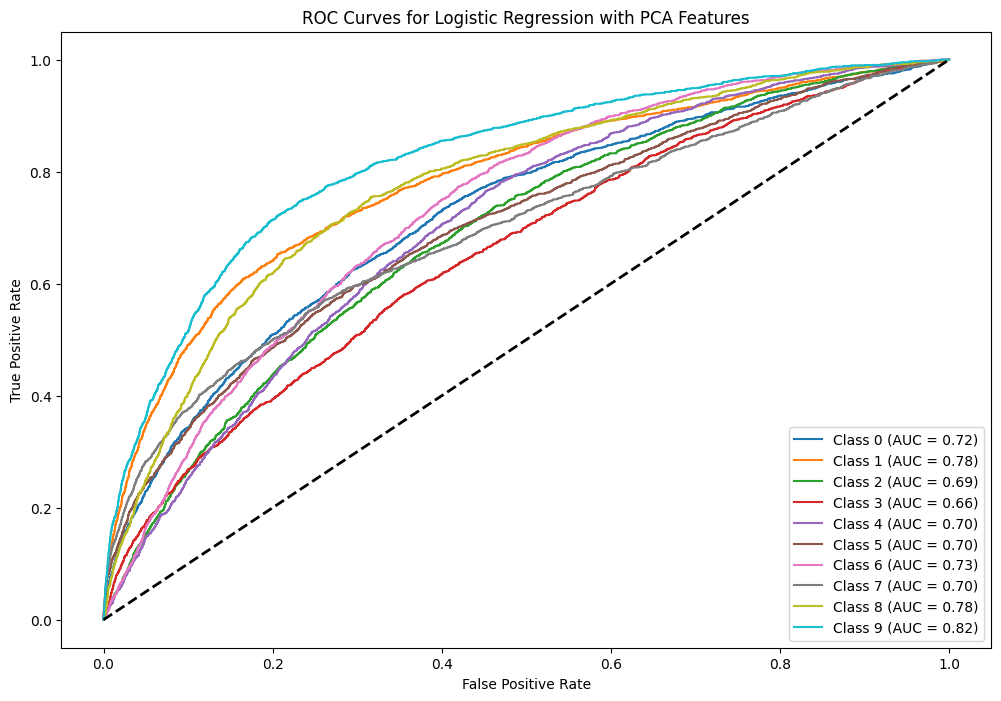

```python
# Step 5: Flatten images for PCA
X_train_flat = X_train.reshape(X_train.shape[0], -1)
X_test_flat = X_test.reshape(X_test.shape[0], -1)

# Standardize the flattened data
scaler = StandardScaler()
X_train_scaled = scaler.fit_transform(X_train_flat)
X_test_scaled = scaler.transform(X_test_flat)

# Apply PCA to retain 95% of the variance
pca = PCA(0.95)
X_train_pca = pca.fit_transform(X_train_scaled)
X_test_pca = pca.transform(X_test_scaled)

print("Original training data shape:", X_train_scaled.shape)
print("Reduced training data shape (PCA):", X_train_pca.shape)

# Step 6: Train Logistic Regression on PCA features
log_reg = LogisticRegression(max_iter=1000, multi_class='multinomial')
log_reg.fit(X_train_pca, y_train.ravel())

# Predict probabilities for the test set
y_pred_proba = log_reg.predict_proba(X_test_pca)

# Step 7: Compute ROC curve for each class
fpr = {}
tpr = {}
roc_auc = {}
for i in range(10):
    fpr[i], tpr[i], _ = roc_curve((y_test == i).astype(int), y_pred_proba[:, i])
    roc_auc[i] = auc(fpr[i], tpr[i])

# Plot ROC curves
plt.figure(figsize=(12, 8))
for i in range(10):
    plt.plot(fpr[i], tpr[i], label=f"Class {i} (AUC = {roc_auc[i]:.2f})")
plt.plot([0, 1], [0, 1], 'k--', lw=2)
plt.xlabel('False Positive Rate')
plt.ylabel('True Positive Rate')
plt.title('ROC Curves for Logistic Regression with PCA Features')
plt.legend(loc='best')
plt.show()
```

```
Number of components for 95% variance: 162
Reduced training data shape (Randomized PCA): (42000, 162)
```

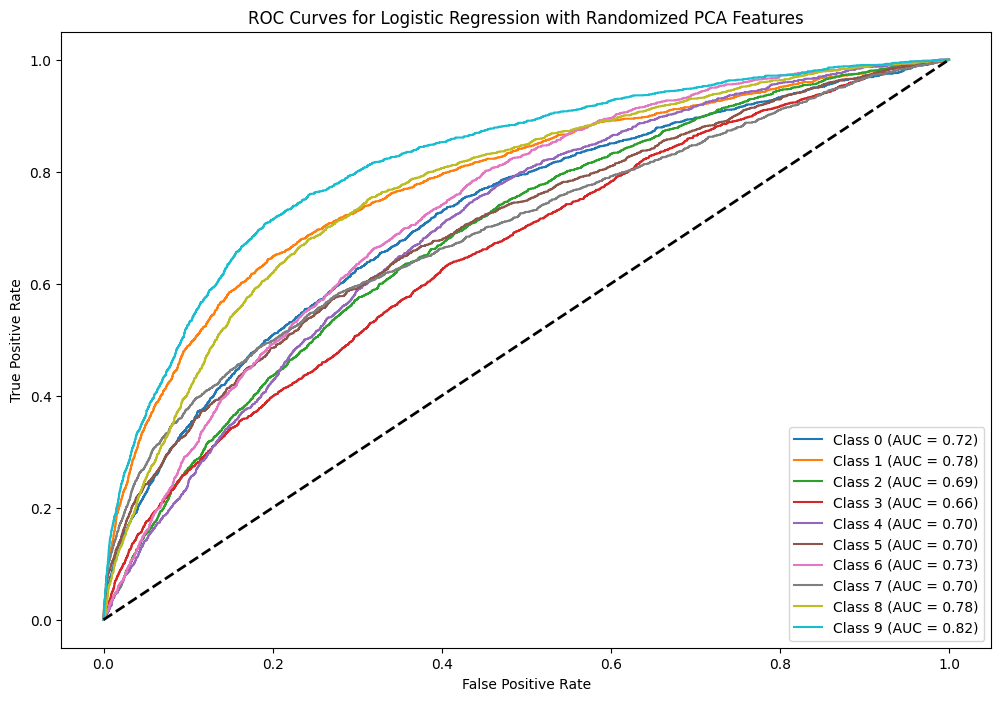

```
Standard PCA Explained Variance Ratio: 0.9500243669137681
Randomized PCA Explained Variance Ratio: 0.9496929394502427
```

```python
# Apply Randomized PCA to retain 95% of the variance
# Determine the number of components for 95% variance with default PCA
pca_temp = PCA(0.95)
pca_temp.fit(X_train_scaled)
num_components = pca_temp.n_components_
print(f"Number of components for 95% variance: {num_components}")

# Apply Randomized PCA using the determined number of components
random_pca = PCA(n_components=num_components, svd_solver='randomized')
X_train_random_pca = random_pca.fit_transform(X_train_scaled)
X_test_random_pca = random_pca.transform(X_test_scaled)

print("Reduced training data shape (Randomized PCA):", X_train_random_pca.shape)

# Train Logistic Regression on Randomized PCA features
log_reg_random = LogisticRegression(max_iter=1000, multi_class='multinomial')
log_reg_random.fit(X_train_random_pca, y_train.ravel())

# Predict probabilities for the test set (Randomized PCA)
y_pred_random_proba = log_reg_random.predict_proba(X_test_random_pca)

# Compute ROC curve for each class
fpr_random = {}
tpr_random = {}
roc_auc_random = {}
for i in range(10):
    fpr_random[i], tpr_random[i], _ = roc_curve((y_test == i).astype(int), y_pred_random_proba[:, i])
    roc_auc_random[i] = auc(fpr_random[i], tpr_random[i])

# Plot ROC curves for Randomized PCA
plt.figure(figsize=(12, 8))
for i in range(10):
    plt.plot(fpr_random[i], tpr_random[i], label=f"Class {i} (AUC = {roc_auc_random[i]:.2f})")
plt.plot([0, 1], [0, 1], 'k--', lw=2)
plt.xlabel('False Positive Rate')
plt.ylabel('True Positive Rate')
plt.title('ROC Curves for Logistic Regression with Randomized PCA Features')
plt.legend(loc='best')
plt.show()

# Compare standard PCA vs Randomized PCA results
print("Standard PCA Explained Variance Ratio:", sum(pca.explained_variance_ratio_))
print("Randomized PCA Explained Variance Ratio:", sum(random_pca.explained_variance_ratio_))
```

```
Test Accuracy (Logistic Regression + Standard PCA): 0.2985555555555556
Classification Report (Standard PCA):
              precision    recall  f1-score   support

           0       0.28      0.31      0.29      1802
           1       0.35      0.39      0.37      1804
           2       0.26      0.19      0.22      1813
           3       0.25      0.15      0.18      1873
           4       0.24      0.22      0.23      1766
           5       0.29      0.27      0.28      1843
           6       0.27      0.32      0.29      1705
           7       0.32      0.32      0.32      1788
           8       0.31      0.38      0.34      1814
           9       0.37      0.45      0.41      1792

    accuracy                           0.30     18000
   macro avg       0.29      0.30      0.29     18000
weighted avg       0.29      0.30      0.29     18000


Test Accuracy (Logistic Regression + Randomized PCA): 0.2980555555555556
Classification Report (Randomized PCA):
              precision    recall  f1-score   support

           0       0.28      0.31      0.29      1802
           1       0.36      0.39      0.37      1804
           2       0.25      0.18      0.21      1813
           3       0.24      0.14      0.18      1873
           4       0.24      0.22      0.23      1766
           5       0.29      0.27      0.28      1843
           6       0.26      0.32      0.29      1705
           7       0.32      0.32      0.32      1788
           8       0.31      0.38      0.34      1814
           9       0.38      0.45      0.41      1792

    accuracy                           0.30     18000
   macro avg       0.29      0.30      0.29     18000
weighted avg       0.29      0.30      0.29     18000


Comparison of PCA vs. Randomized PCA:
 - Standard PCA accuracy:       0.2986
 - Randomized PCA accuracy:     0.2981
 - Standard PCA explained var:  0.9500
 - Randomized PCA explained var:0.9497
Observations: Randomized PCA often yields similar results but can be faster for large dimensional data, etc.
```

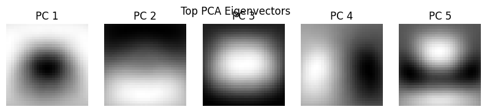

```python
y_pred_pca = log_reg.predict(X_test_pca)
pca_accuracy = accuracy_score(y_test, y_pred_pca)
print("Test Accuracy (Logistic Regression + Standard PCA):", pca_accuracy)
print("Classification Report (Standard PCA):")
print(classification_report(y_test, y_pred_pca))

# -----------------------------
# 1B. Evaluate classification performance (Randomized PCA)
# -----------------------------
y_pred_random_pca = log_reg_random.predict(X_test_random_pca)
random_pca_accuracy = accuracy_score(y_test, y_pred_random_pca)
print("\nTest Accuracy (Logistic Regression + Randomized PCA):", random_pca_accuracy)
print("Classification Report (Randomized PCA):")
print(classification_report(y_test, y_pred_random_pca))

# -----------------------------
# 2. Compare both PCA methods
# -----------------------------
print("\nComparison of PCA vs. Randomized PCA:")
print(f" - Standard PCA accuracy:       {pca_accuracy:.4f}")
print(f" - Randomized PCA accuracy:     {random_pca_accuracy:.4f}")
print(f" - Standard PCA explained var:  {sum(pca.explained_variance_ratio_):.4f}")
print(f" - Randomized PCA explained var:{sum(random_pca.explained_variance_ratio_):.4f}")
print("Observations: Randomized PCA often yields similar results but can be faster for large dimensional data, etc.")

# -----------------------------
# 3. Visualize top PCA eigenvectors
# -----------------------------
num_eigenvectors_to_show = 5
plt.figure(figsize=(10, 2))
for i in range(num_eigenvectors_to_show):
    ax = plt.subplot(1, num_eigenvectors_to_show, i + 1)
    # pca.components_[i] has shape (input_dim,), reshape to (32,32)
    # Note: X_train_scaled was flattened from (32, 32) -> 1024, so if your shape is 1024
    # you can reshape to (32, 32).
    plt.imshow(pca.components_[i].reshape(32, 32), cmap='gray')
    plt.axis('off')
    plt.title(f"PC {i+1}")
plt.suptitle("Top PCA Eigenvectors")
plt.show()
```

### Discussion:

We observe that the top principal components capture broad grayscale patterns.

## Task 2: Train a single layer autoencoder with linear activation function and appropriately mean and variance normalized input with constraint that encoder weight matrix and decoder weight matrix are transpose w,r,t, each other. Compare the eigenvectors obtained in step 1 with those obtained using the autoencoders. Explain your observations.

```python
# Input dimensions
input_dim = X_train_scaled.shape[1]  # Number of features after flattening
latent_dim = X_train_pca.shape[1]  # Match PCA latent dimension

# Define the encoder
input_layer = Input(shape=(input_dim,))
encoder_layer = Dense(latent_dim, activation='linear', name='encoder_layer')
encoded = encoder_layer(input_layer)

# Define the decoder using tied weights
def tied_decoder(encoded_input, encoder_layer):
    tied_weights = K.transpose(encoder_layer.kernel)  # Transpose the encoder weights
    return K.dot(encoded_input, tied_weights)

# Use Lambda layer for tied weights
decoded = tf.keras.layers.Lambda(
    lambda x: tied_decoder(x, encoder_layer=encoder_layer),
    name='decoder'
)(encoded)

# Build the autoencoder model
autoencoder = Model(inputs=input_layer, outputs=decoded)
autoencoder.compile(optimizer='adam', loss='mse')

# Train the autoencoder
history = autoencoder.fit(
    X_train_scaled, X_train_scaled,  # Use the scaled training data
    epochs=50,
    batch_size=256,
    validation_data=(X_test_scaled, X_test_scaled),  # Use the scaled testing data
    verbose=1
)

# Extract the encoder model to get latent representations
encoder_model = Model(inputs=input_layer, outputs=encoded)
X_train_autoencoded = encoder_model.predict(X_train_scaled)
X_test_autoencoded = encoder_model.predict(X_test_scaled)

# Print latent space shape
print("Latent space shape:", X_train_autoencoded.shape)
```

```
165/165 ━━━━━━━━━━━━━━━━━━━━ 5s 23ms/step - loss: 0.3848 - val_loss: 0.1243
165/165 ━━━━━━━━━━━━━━━━━━━━ 2s 14ms/step - loss: 0.1102 - val_loss: 0.0857
165/165 ━━━━━━━━━━━━━━━━━━━━ 3s 14ms/step - loss: 0.0806 - val_loss: 0.0710
165/165 ━━━━━━━━━━━━━━━━━━━━ 3s 14ms/step - loss: 0.0679 - val_loss: 0.0630
165/165 ━━━━━━━━━━━━━━━━━━━━ 3s 17ms/step - loss: 0.0608 - val_loss: 0.0584
165/165 ━━━━━━━━━━━━━━━━━━━━ 5s 14ms/step - loss: 0.0570 - val_loss: 0.0561
165/165 ━━━━━━━━━━━━━━━━━━━━ 3s 14ms/step - loss: 0.0547 - val_loss: 0.0551
165/165 ━━━━━━━━━━━━━━━━━━━━ 3s 14ms/step - loss: 0.0541 - val_loss: 0.0544
165/165 ━━━━━━━━━━━━━━━━━━━━ 3s 18ms/step - loss: 0.0532 - val_loss: 0.0538
165/165 ━━━━━━━━━━━━━━━━━━━━ 4s 14ms/step - loss: 0.0527 - val_loss: 0.0537
165/165 ━━━━━━━━━━━━━━━━━━━━ 2s 14ms/step - loss: 0.0528 - val_loss: 0.0535
165/165 ━━━━━━━━━━━━━━━━━━━━ 2s 14ms/step - loss: 0.0527 - val_loss: 0.0534
165/165 ━━━━━━━━━━━━━━━━━━━━ 3s 18ms/step - loss: 0.0524 - val_loss: 0.0534
165/165 ━━━━━━━━━━━━━━━━━━━━ 3s 20ms/step - loss: 0.0525 - val_loss: 0.0533
165/165 ━━━━━━━━━━━━━━━━━━━━ 2s 14ms/step - loss: 0.0527 - val_loss: 0.0533
165/165 ━━━━━━━━━━━━━━━━━━━━ 2s 14ms/step - loss: 0.0528 - val_loss: 0.0533
165/165 ━━━━━━━━━━━━━━━━━━━━ 3s 14ms/step - loss: 0.0524 - val_loss: 0.0532
165/165 ━━━━━━━━━━━━━━━━━━━━ 3s 16ms/step - loss: 0.0527 - val_loss: 0.0532
165/165 ━━━━━━━━━━━━━━━━━━━━ 5s 16ms/step - loss: 0.0529 - val_loss: 0.0533
165/165 ━━━━━━━━━━━━━━━━━━━━ 5s 14ms/step - loss: 0.0527 - val_loss: 0.0531
165/165 ━━━━━━━━━━━━━━━━━━━━ 4s 23ms/step - loss: 0.0526 - val_loss: 0.0531
165/165 ━━━━━━━━━━━━━━━━━━━━ 3s 17ms/step - loss: 0.0526 - val_loss: 0.0531
165/165 ━━━━━━━━━━━━━━━━━━━━ 5s 14ms/step - loss: 0.0524 - val_loss: 0.0531
165/165 ━━━━━━━━━━━━━━━━━━━━ 3s 14ms/step - loss: 0.0525 - val_loss: 0.0532
165/165 ━━━━━━━━━━━━━━━━━━━━ 3s 19ms/step - loss: 0.0528 - val_loss: 0.0532
165/165 ━━━━━━━━━━━━━━━━━━━━ 4s 14ms/step - loss: 0.0526 - val_loss: 0.0531
165/165 ━━━━━━━━━━━━━━━━━━━━ 3s 14ms/step - loss: 0.0526 - val_loss: 0.0530
165/165 ━━━━━━━━━━━━━━━━━━━━ 2s 14ms/step - loss: 0.0525 - val_loss: 0.0530
165/165 ━━━━━━━━━━━━━━━━━━━━ 3s 18ms/step - loss: 0.0523 - val_loss: 0.0531
165/165 ━━━━━━━━━━━━━━━━━━━━ 3s 20ms/step - loss: 0.0524 - val_loss: 0.0530
165/165 ━━━━━━━━━━━━━━━━━━━━ 2s 14ms/step - loss: 0.0524 - val_loss: 0.0531
165/165 ━━━━━━━━━━━━━━━━━━━━ 2s 14ms/step - loss: 0.0523 - val_loss: 0.0530
165/165 ━━━━━━━━━━━━━━━━━━━━ 3s 14ms/step - loss: 0.0523 - val_loss: 0.0530
165/165 ━━━━━━━━━━━━━━━━━━━━ 3s 17ms/step - loss: 0.0522 - val_loss: 0.0530
165/165 ━━━━━━━━━━━━━━━━━━━━ 3s 21ms/step - loss: 0.0525 - val_loss: 0.0530
165/165 ━━━━━━━━━━━━━━━━━━━━ 2s 14ms/step - loss: 0.0526 - val_loss: 0.0530
165/165 ━━━━━━━━━━━━━━━━━━━━ 2s 14ms/step - loss: 0.0530 - val_loss: 0.0530
165/165 ━━━━━━━━━━━━━━━━━━━━ 3s 14ms/step - loss: 0.0527 - val_loss: 0.0530
165/165 ━━━━━━━━━━━━━━━━━━━━ 3s 16ms/step - loss: 0.0524 - val_loss: 0.0530
165/165 ━━━━━━━━━━━━━━━━━━━━ 5s 14ms/step - loss: 0.0525 - val_loss: 0.0530
165/165 ━━━━━━━━━━━━━━━━━━━━ 3s 14ms/step - loss: 0.0527 - val_loss: 0.0530
165/165 ━━━━━━━━━━━━━━━━━━━━ 2s 14ms/step - loss: 0.0527 - val_loss: 0.0530
165/165 ━━━━━━━━━━━━━━━━━━━━ 3s 17ms/step - loss: 0.0526 - val_loss: 0.0529
165/165 ━━━━━━━━━━━━━━━━━━━━ 4s 21ms/step - loss: 0.0524 - val_loss: 0.0530
165/165 ━━━━━━━━━━━━━━━━━━━━ 4s 14ms/step - loss: 0.0525 - val_loss: 0.0529
165/165 ━━━━━━━━━━━━━━━━━━━━ 3s 14ms/step - loss: 0.0525 - val_loss: 0.0529
165/165 ━━━━━━━━━━━━━━━━━━━━ 3s 14ms/step - loss: 0.0524 - val_loss: 0.0529
165/165 ━━━━━━━━━━━━━━━━━━━━ 4s 23ms/step - loss: 0.0524 - val_loss: 0.0529
165/165 ━━━━━━━━━━━━━━━━━━━━ 4s 14ms/step - loss: 0.0523 - val_loss: 0.0529
165/165 ━━━━━━━━━━━━━━━━━━━━ 2s 14ms/step - loss: 0.0526 - val_loss: 0.0529
1313/1313 ━━━━━━━━━━━━━━━━━━━━ 2s 1ms/step
563/563 ━━━━━━━━━━━━━━━━━━━━ 1s 1ms/step
Latent space shape: (42000, 162)
```

```
Component/Neuron 0 correlation (AE vs. PCA): 0.0053
Component/Neuron 1 correlation (AE vs. PCA): -0.0028
Component/Neuron 2 correlation (AE vs. PCA): 0.0000
Component/Neuron 3 correlation (AE vs. PCA): 0.0015
Component/Neuron 4 correlation (AE vs. PCA): -0.0023
Component/Neuron 5 correlation (AE vs. PCA): 0.0001
Component/Neuron 6 correlation (AE vs. PCA): -0.0076
Component/Neuron 7 correlation (AE vs. PCA): -0.0020
Component/Neuron 8 correlation (AE vs. PCA): -0.0014
Component/Neuron 9 correlation (AE vs. PCA): 0.0091
Component/Neuron 10 correlation (AE vs. PCA): 0.0242
Component/Neuron 11 correlation (AE vs. PCA): -0.0136
Component/Neuron 12 correlation (AE vs. PCA): -0.0444
Component/Neuron 13 correlation (AE vs. PCA): -0.0002
Component/Neuron 14 correlation (AE vs. PCA): -0.0634
Component/Neuron 15 correlation (AE vs. PCA): -0.0126
Component/Neuron 16 correlation (AE vs. PCA): 0.0119
Component/Neuron 17 correlation (AE vs. PCA): 0.0018
Component/Neuron 18 correlation (AE vs. PCA): 0.0602
Component/Neuron 19 correlation (AE vs. PCA): 0.0286
Component/Neuron 20 correlation (AE vs. PCA): -0.1888
Component/Neuron 21 correlation (AE vs. PCA): -0.0254
Component/Neuron 22 correlation (AE vs. PCA): 0.0714
Component/Neuron 23 correlation (AE vs. PCA): 0.1061
Component/Neuron 24 correlation (AE vs. PCA): 0.0275
Component/Neuron 25 correlation (AE vs. PCA): 0.0122
Component/Neuron 26 correlation (AE vs. PCA): -0.1527
Component/Neuron 27 correlation (AE vs. PCA): -0.0942
Component/Neuron 28 correlation (AE vs. PCA): 0.0127
Component/Neuron 29 correlation (AE vs. PCA): 0.0029
Component/Neuron 30 correlation (AE vs. PCA): -0.0829
Component/Neuron 31 correlation (AE vs. PCA): 0.0058
Component/Neuron 32 correlation (AE vs. PCA): 0.1336
Component/Neuron 33 correlation (AE vs. PCA): -0.1021
Component/Neuron 34 correlation (AE vs. PCA): 0.0554
Component/Neuron 35 correlation (AE vs. PCA): 0.1733
Component/Neuron 36 correlation (AE vs. PCA): 0.0038
Component/Neuron 37 correlation (AE vs. PCA): -0.0891
Component/Neuron 38 correlation (AE vs. PCA): -0.0314
Component/Neuron 39 correlation (AE vs. PCA): 0.0570
```

[output cut: 107 more lines]

```
Component/Neuron 147 correlation (AE vs. PCA): -0.3031
Component/Neuron 148 correlation (AE vs. PCA): -0.0775
Component/Neuron 149 correlation (AE vs. PCA): -0.0532
Component/Neuron 150 correlation (AE vs. PCA): 0.2309
Component/Neuron 151 correlation (AE vs. PCA): 0.1376
Component/Neuron 152 correlation (AE vs. PCA): -0.0603
Component/Neuron 153 correlation (AE vs. PCA): -0.0347
Component/Neuron 154 correlation (AE vs. PCA): -0.0928
Component/Neuron 155 correlation (AE vs. PCA): 0.1175
Component/Neuron 156 correlation (AE vs. PCA): -0.0232
Component/Neuron 157 correlation (AE vs. PCA): -0.0202
Component/Neuron 158 correlation (AE vs. PCA): -0.1126
Component/Neuron 159 correlation (AE vs. PCA): 0.0066
Component/Neuron 160 correlation (AE vs. PCA): 0.0357
Component/Neuron 161 correlation (AE vs. PCA): -0.0082
```

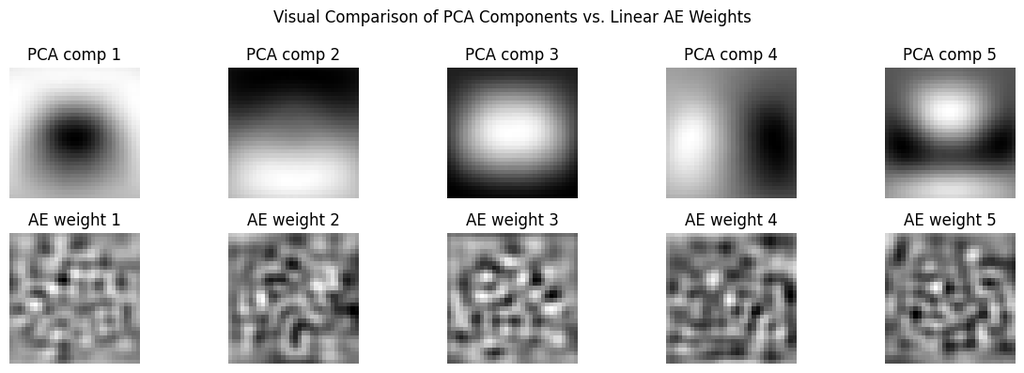

```python
# -----------------------------
# Compare autoencoder encoder weights to PCA components
# -----------------------------
# PCA components_ shape: (n_components, input_dim)
# AE encoder weights shape: (input_dim, latent_dim)
# Transpose AE encoder weights to get (latent_dim, input_dim)

ae_weights = encoder_layer.get_weights()[0]      # shape -> (input_dim, latent_dim)
ae_weights_t = ae_weights.T                      # shape -> (latent_dim, input_dim)
pca_components = pca.components_                # shape -> (n_components, input_dim)

correlations = []
for i in range(latent_dim):
    corr = np.corrcoef(ae_weights_t[i], pca_components[i])[0, 1]
    correlations.append(corr)

for i, c in enumerate(correlations):
    print(f"Component/Neuron {i} correlation (AE vs. PCA): {c:.4f}")

# Optional: visualize side by side
num_components_to_show = min(latent_dim, 5)
plt.figure(figsize=(12, 4))
for i in range(num_components_to_show):
    # PCA component i
    plt.subplot(2, num_components_to_show, i+1)
    plt.imshow(pca_components[i].reshape(32, 32), cmap='gray')
    plt.title(f"PCA comp {i+1}")
    plt.axis('off')

    # AE weights i
    plt.subplot(2, num_components_to_show, num_components_to_show + i + 1)
    plt.imshow(ae_weights_t[i].reshape(32, 32), cmap='gray')
    plt.title(f"AE weight {i+1}")
    plt.axis('off')

plt.suptitle("Visual Comparison of PCA Components vs. Linear AE Weights")
plt.tight_layout()
plt.show()
```

### Task 3:

```python
# Reshape your training/testing data from (N, 32, 32) to (N, 32, 32, 1)
X_train_cae = X_train[..., np.newaxis]  # shape -> (N, 32, 32, 1)
X_test_cae = X_test[..., np.newaxis]    # shape -> (N, 32, 32, 1)

# Use the same scaling (already /255.0) or apply standardization if needed
# e.g., X_train_cae = scaler_for_images.fit_transform(X_train_cae.reshape(...)).reshape(...)

##############################################################################
# 1. Define the architecture
##############################################################################
latent_dim = X_train_pca.shape[1]  # from Task 2

# ----- Encoder -----
encoder_input = layers.Input(shape=(32, 32, 1))

x = layers.Conv2D(filters=32, kernel_size=3, activation='relu', padding='same')(encoder_input)
x = layers.MaxPooling2D(pool_size=2, padding='same')(x)  # shape -> (16,16,32)

x = layers.Conv2D(filters=64, kernel_size=3, activation='relu', padding='same')(x)
x = layers.MaxPooling2D(pool_size=2, padding='same')(x)  # shape -> (8,8,64)

x = layers.Conv2D(filters=128, kernel_size=3, activation='relu', padding='same')(x)
x = layers.MaxPooling2D(pool_size=2, padding='same')(x)  # shape -> (4,4,128)

# Flatten
x = layers.Flatten()(x)  # shape -> (4*4*128) = 2048 if 4x4 with 128 filters

# Dense layer to go down to the latent space
encoded = layers.Dense(latent_dim, activation='relu')(x)

# ----- Decoder -----
# We need to reverse the process in the decoder.
# First go from latent_dim -> shape that matches (4,4,128)
decoder_input = layers.Dense(4*4*128, activation='relu')(encoded)

x = layers.Reshape((4, 4, 128))(decoder_input)

x = layers.Conv2DTranspose(filters=128, kernel_size=3, strides=2, activation='relu',
                           padding='same', output_padding=1)(x)  # shape -> (8,8,128)

x = layers.Conv2DTranspose(filters=64, kernel_size=3, strides=2, activation='relu',
                           padding='same', output_padding=1)(x)  # shape -> (16,16,64)

x = layers.Conv2DTranspose(filters=32, kernel_size=3, strides=2, activation='relu',
                           padding='same', output_padding=1)(x)  # shape -> (32,32,32)

# Output = 1 channel (grayscale), linear or sigmoid (try both)
decoded = layers.Conv2DTranspose(filters=1, kernel_size=3, activation='sigmoid',
                                 padding='same')(x)

# Build the model
conv_autoencoder = models.Model(encoder_input, decoded)
conv_autoencoder.compile(optimizer='adam', loss='mse')
conv_autoencoder.summary()

##############################################################################
# 2. Train the deep Conv Autoencoder
##############################################################################
epochs = 50
batch_size = 128
history_convAE = conv_autoencoder.fit(
    X_train_cae, X_train_cae,
    epochs=epochs,
    batch_size=batch_size,
    shuffle=True,
    validation_data=(X_test_cae, X_test_cae)
)

##############################################################################
# 3. Compute reconstruction error
##############################################################################
# Use MSE on the test set
X_test_pred = conv_autoencoder.predict(X_test_cae)
reconstruction_error_convAE = np.mean((X_test_cae - X_test_pred)**2)
print("Conv Autoencoder Test Reconstruction Error:", reconstruction_error_convAE)
```

```
Model: "functional_2"
```

```
┏━━━━━━━━━━━━━━━━━━━━━━━━━━━━━━━━━━━━━━┳━━━━━━━━━━━━━━━━━━━━━━━━━━━━━┳━━━━━━━━━━━━━━━━━┓
┃ Layer (type)                         ┃ Output Shape                ┃         Param # ┃
┡━━━━━━━━━━━━━━━━━━━━━━━━━━━━━━━━━━━━━━╇━━━━━━━━━━━━━━━━━━━━━━━━━━━━━╇━━━━━━━━━━━━━━━━━┩
│ input_layer_1 (InputLayer)           │ (None, 32, 32, 1)           │               0 │
├──────────────────────────────────────┼─────────────────────────────┼─────────────────┤
│ conv2d (Conv2D)                      │ (None, 32, 32, 32)          │             320 │
├──────────────────────────────────────┼─────────────────────────────┼─────────────────┤
│ max_pooling2d (MaxPooling2D)         │ (None, 16, 16, 32)          │               0 │
├──────────────────────────────────────┼─────────────────────────────┼─────────────────┤
│ conv2d_1 (Conv2D)                    │ (None, 16, 16, 64)          │          18,496 │
├──────────────────────────────────────┼─────────────────────────────┼─────────────────┤
│ max_pooling2d_1 (MaxPooling2D)       │ (None, 8, 8, 64)            │               0 │
├──────────────────────────────────────┼─────────────────────────────┼─────────────────┤
│ conv2d_2 (Conv2D)                    │ (None, 8, 8, 128)           │          73,856 │
├──────────────────────────────────────┼─────────────────────────────┼─────────────────┤
│ max_pooling2d_2 (MaxPooling2D)       │ (None, 4, 4, 128)           │               0 │
├──────────────────────────────────────┼─────────────────────────────┼─────────────────┤
│ flatten (Flatten)                    │ (None, 2048)                │               0 │
├──────────────────────────────────────┼─────────────────────────────┼─────────────────┤
│ dense (Dense)                        │ (None, 162)                 │         331,938 │
├──────────────────────────────────────┼─────────────────────────────┼─────────────────┤
│ dense_1 (Dense)                      │ (None, 2048)                │         333,824 │
├──────────────────────────────────────┼─────────────────────────────┼─────────────────┤
│ reshape (Reshape)                    │ (None, 4, 4, 128)           │               0 │
├──────────────────────────────────────┼─────────────────────────────┼─────────────────┤
│ conv2d_transpose (Conv2DTranspose)   │ (None, 8, 8, 128)           │         147,584 │
├──────────────────────────────────────┼─────────────────────────────┼─────────────────┤
│ conv2d_transpose_1 (Conv2DTranspose) │ (None, 16, 16, 64)          │          73,792 │
├──────────────────────────────────────┼─────────────────────────────┼─────────────────┤
│ conv2d_transpose_2 (Conv2DTranspose) │ (None, 32, 32, 32)          │          18,464 │
├──────────────────────────────────────┼─────────────────────────────┼─────────────────┤
│ conv2d_transpose_3 (Conv2DTranspose) │ (None, 32, 32, 1)           │             289 │
└──────────────────────────────────────┴─────────────────────────────┴─────────────────┘
```

```
 Total params: 998,563 (3.81 MB)
```

```
 Trainable params: 998,563 (3.81 MB)
```

```
 Non-trainable params: 0 (0.00 B)
```

```
329/329 ━━━━━━━━━━━━━━━━━━━━ 203s 608ms/step - loss: 0.0397 - val_loss: 4.4711e-06
329/329 ━━━━━━━━━━━━━━━━━━━━ 189s 574ms/step - loss: 4.4520e-06 - val_loss: 4.4711e-06
329/329 ━━━━━━━━━━━━━━━━━━━━ 203s 577ms/step - loss: 4.4592e-06 - val_loss: 4.4711e-06
329/329 ━━━━━━━━━━━━━━━━━━━━ 232s 707ms/step - loss: 4.4598e-06 - val_loss: 4.4711e-06
329/329 ━━━━━━━━━━━━━━━━━━━━ 248s 664ms/step - loss: 4.4640e-06 - val_loss: 4.4711e-06
329/329 ━━━━━━━━━━━━━━━━━━━━ 232s 573ms/step - loss: 4.4611e-06 - val_loss: 4.4711e-06
329/329 ━━━━━━━━━━━━━━━━━━━━ 190s 577ms/step - loss: 4.4424e-06 - val_loss: 4.4711e-06
329/329 ━━━━━━━━━━━━━━━━━━━━ 216s 620ms/step - loss: 4.4614e-06 - val_loss: 4.4711e-06
329/329 ━━━━━━━━━━━━━━━━━━━━ 249s 581ms/step - loss: 4.4528e-06 - val_loss: 4.4711e-06
329/329 ━━━━━━━━━━━━━━━━━━━━ 199s 572ms/step - loss: 4.4437e-06 - val_loss: 4.4711e-06
329/329 ━━━━━━━━━━━━━━━━━━━━ 203s 576ms/step - loss: 4.4372e-06 - val_loss: 4.4711e-06
329/329 ━━━━━━━━━━━━━━━━━━━━ 200s 572ms/step - loss: 4.4562e-06 - val_loss: 4.4711e-06
329/329 ━━━━━━━━━━━━━━━━━━━━ 202s 572ms/step - loss: 4.4308e-06 - val_loss: 4.4711e-06
329/329 ━━━━━━━━━━━━━━━━━━━━ 201s 571ms/step - loss: 4.4701e-06 - val_loss: 4.4711e-06
329/329 ━━━━━━━━━━━━━━━━━━━━ 203s 573ms/step - loss: 4.4637e-06 - val_loss: 4.4711e-06
329/329 ━━━━━━━━━━━━━━━━━━━━ 201s 572ms/step - loss: 4.4625e-06 - val_loss: 4.4711e-06
329/329 ━━━━━━━━━━━━━━━━━━━━ 201s 568ms/step - loss: 4.4551e-06 - val_loss: 4.4711e-06
329/329 ━━━━━━━━━━━━━━━━━━━━ 189s 575ms/step - loss: 4.4725e-06 - val_loss: 4.4711e-06
329/329 ━━━━━━━━━━━━━━━━━━━━ 201s 572ms/step - loss: 4.4557e-06 - val_loss: 4.4711e-06
329/329 ━━━━━━━━━━━━━━━━━━━━ 202s 573ms/step - loss: 4.4451e-06 - val_loss: 4.4711e-06
329/329 ━━━━━━━━━━━━━━━━━━━━ 189s 574ms/step - loss: 4.4645e-06 - val_loss: 4.4711e-06
329/329 ━━━━━━━━━━━━━━━━━━━━ 200s 569ms/step - loss: 4.4553e-06 - val_loss: 4.4711e-06
329/329 ━━━━━━━━━━━━━━━━━━━━ 202s 568ms/step - loss: 4.4431e-06 - val_loss: 4.4711e-06
329/329 ━━━━━━━━━━━━━━━━━━━━ 202s 570ms/step - loss: 4.4547e-06 - val_loss: 4.4711e-06
329/329 ━━━━━━━━━━━━━━━━━━━━ 221s 626ms/step - loss: 4.4532e-06 - val_loss: 4.4711e-06
329/329 ━━━━━━━━━━━━━━━━━━━━ 243s 569ms/step - loss: 4.4539e-06 - val_loss: 4.4711e-06
329/329 ━━━━━━━━━━━━━━━━━━━━ 188s 573ms/step - loss: 4.4463e-06 - val_loss: 4.4711e-06
329/329 ━━━━━━━━━━━━━━━━━━━━ 203s 576ms/step - loss: 4.4562e-06 - val_loss: 4.4711e-06
329/329 ━━━━━━━━━━━━━━━━━━━━ 189s 575ms/step - loss: 4.4474e-06 - val_loss: 4.4711e-06
329/329 ━━━━━━━━━━━━━━━━━━━━ 201s 574ms/step - loss: 4.4603e-06 - val_loss: 4.4711e-06
329/329 ━━━━━━━━━━━━━━━━━━━━ 201s 571ms/step - loss: 4.4568e-06 - val_loss: 4.4711e-06
329/329 ━━━━━━━━━━━━━━━━━━━━ 188s 572ms/step - loss: 4.4577e-06 - val_loss: 4.4711e-06
329/329 ━━━━━━━━━━━━━━━━━━━━ 190s 576ms/step - loss: 4.4522e-06 - val_loss: 4.4711e-06
329/329 ━━━━━━━━━━━━━━━━━━━━ 201s 575ms/step - loss: 4.4472e-06 - val_loss: 4.4711e-06
329/329 ━━━━━━━━━━━━━━━━━━━━ 202s 575ms/step - loss: 4.4571e-06 - val_loss: 4.4711e-06
329/329 ━━━━━━━━━━━━━━━━━━━━ 189s 573ms/step - loss: 4.4441e-06 - val_loss: 4.4711e-06
329/329 ━━━━━━━━━━━━━━━━━━━━ 203s 576ms/step - loss: 4.4705e-06 - val_loss: 4.4711e-06
329/329 ━━━━━━━━━━━━━━━━━━━━ 201s 574ms/step - loss: 4.4474e-06 - val_loss: 4.4711e-06
329/329 ━━━━━━━━━━━━━━━━━━━━ 189s 576ms/step - loss: 4.4531e-06 - val_loss: 4.4711e-06
329/329 ━━━━━━━━━━━━━━━━━━━━ 202s 575ms/step - loss: 4.4402e-06 - val_loss: 4.4711e-06
329/329 ━━━━━━━━━━━━━━━━━━━━ 188s 572ms/step - loss: 4.4284e-06 - val_loss: 4.4711e-06
329/329 ━━━━━━━━━━━━━━━━━━━━ 202s 572ms/step - loss: 4.4506e-06 - val_loss: 4.4711e-06
329/329 ━━━━━━━━━━━━━━━━━━━━ 201s 570ms/step - loss: 4.4604e-06 - val_loss: 4.4711e-06
329/329 ━━━━━━━━━━━━━━━━━━━━ 206s 582ms/step - loss: 4.4517e-06 - val_loss: 4.4711e-06
329/329 ━━━━━━━━━━━━━━━━━━━━ 201s 577ms/step - loss: 4.4703e-06 - val_loss: 4.4711e-06
329/329 ━━━━━━━━━━━━━━━━━━━━ 191s 580ms/step - loss: 4.4629e-06 - val_loss: 4.4711e-06
329/329 ━━━━━━━━━━━━━━━━━━━━ 202s 579ms/step - loss: 4.4637e-06 - val_loss: 4.4711e-06
329/329 ━━━━━━━━━━━━━━━━━━━━ 200s 573ms/step - loss: 4.4665e-06 - val_loss: 4.4711e-06
329/329 ━━━━━━━━━━━━━━━━━━━━ 202s 572ms/step - loss: 4.4627e-06 - val_loss: 4.4711e-06
329/329 ━━━━━━━━━━━━━━━━━━━━ 202s 571ms/step - loss: 4.4456e-06 - val_loss: 4.4711e-06
563/563 ━━━━━━━━━━━━━━━━━━━━ 27s 48ms/step
Conv Autoencoder Test Reconstruction Error: 4.4711250331578775e-06
```

### Single-layer linear AE (tied weights) from Task 2

```python
X_test_pred_linear = autoencoder.predict(X_test_scaled)  # autoencoder from Task 2
# MSE across entire test set
reconstruction_error_linear = np.mean((X_test_scaled - X_test_pred_linear)**2)
print("Single-layer linear AE Reconstruction Error:", reconstruction_error_linear)
```

```
563/563 ━━━━━━━━━━━━━━━━━━━━ 1s 2ms/step
Single-layer linear AE Reconstruction Error: 0.05294620016766814
```

### Single hidden layer AE with Sigmoid (encoder) -> Linear (decoder)

```python
input_ae = layers.Input(shape=(input_dim,))
hidden_nodes = X_train_pca.shape[1]
encoded = layers.Dense(hidden_nodes, activation='sigmoid')(input_ae)
decoded = layers.Dense(input_dim, activation='linear')(encoded)

single_hidden_ae = models.Model(input_ae, decoded)
single_hidden_ae.compile(optimizer='adam', loss='mse')
single_hidden_ae.fit(
    X_train_scaled, X_train_scaled,
    epochs=50,
    batch_size=256,
    validation_data=(X_test_scaled, X_test_scaled),
    verbose=1
    )
X_test_pred_single_hidden = single_hidden_ae.predict(X_test_scaled)
reconstruction_error_single_hidden = np.mean((X_test_scaled - X_test_pred_single_hidden)**2)
print("Single Hidden AE Reconstruction Error:", reconstruction_error_single_hidden)
```

```
165/165 ━━━━━━━━━━━━━━━━━━━━ 9s 47ms/step - loss: 0.6002 - val_loss: 0.2778
165/165 ━━━━━━━━━━━━━━━━━━━━ 5s 16ms/step - loss: 0.2519 - val_loss: 0.2030
165/165 ━━━━━━━━━━━━━━━━━━━━ 7s 25ms/step - loss: 0.1882 - val_loss: 0.1693
165/165 ━━━━━━━━━━━━━━━━━━━━ 3s 16ms/step - loss: 0.1569 - val_loss: 0.1438
165/165 ━━━━━━━━━━━━━━━━━━━━ 5s 16ms/step - loss: 0.1365 - val_loss: 0.1301
165/165 ━━━━━━━━━━━━━━━━━━━━ 6s 23ms/step - loss: 0.1233 - val_loss: 0.1233
165/165 ━━━━━━━━━━━━━━━━━━━━ 4s 16ms/step - loss: 0.1124 - val_loss: 0.1116
165/165 ━━━━━━━━━━━━━━━━━━━━ 3s 16ms/step - loss: 0.1055 - val_loss: 0.1034
165/165 ━━━━━━━━━━━━━━━━━━━━ 6s 24ms/step - loss: 0.0986 - val_loss: 0.0983
165/165 ━━━━━━━━━━━━━━━━━━━━ 3s 16ms/step - loss: 0.0927 - val_loss: 0.0945
165/165 ━━━━━━━━━━━━━━━━━━━━ 5s 16ms/step - loss: 0.0892 - val_loss: 0.0900
165/165 ━━━━━━━━━━━━━━━━━━━━ 6s 24ms/step - loss: 0.0853 - val_loss: 0.0918
165/165 ━━━━━━━━━━━━━━━━━━━━ 4s 16ms/step - loss: 0.0832 - val_loss: 0.0966
165/165 ━━━━━━━━━━━━━━━━━━━━ 3s 16ms/step - loss: 0.0800 - val_loss: 0.0813
165/165 ━━━━━━━━━━━━━━━━━━━━ 6s 24ms/step - loss: 0.0775 - val_loss: 0.0791
165/165 ━━━━━━━━━━━━━━━━━━━━ 3s 18ms/step - loss: 0.0754 - val_loss: 0.0794
165/165 ━━━━━━━━━━━━━━━━━━━━ 5s 16ms/step - loss: 0.0739 - val_loss: 0.0773
165/165 ━━━━━━━━━━━━━━━━━━━━ 3s 16ms/step - loss: 0.0723 - val_loss: 0.0757
165/165 ━━━━━━━━━━━━━━━━━━━━ 5s 16ms/step - loss: 0.0714 - val_loss: 0.0732
165/165 ━━━━━━━━━━━━━━━━━━━━ 5s 16ms/step - loss: 0.0696 - val_loss: 0.0748
165/165 ━━━━━━━━━━━━━━━━━━━━ 4s 22ms/step - loss: 0.0690 - val_loss: 0.0720
165/165 ━━━━━━━━━━━━━━━━━━━━ 4s 16ms/step - loss: 0.0680 - val_loss: 0.0728
165/165 ━━━━━━━━━━━━━━━━━━━━ 5s 16ms/step - loss: 0.0676 - val_loss: 0.0710
165/165 ━━━━━━━━━━━━━━━━━━━━ 3s 19ms/step - loss: 0.0666 - val_loss: 0.0796
165/165 ━━━━━━━━━━━━━━━━━━━━ 4s 22ms/step - loss: 0.0671 - val_loss: 0.0704
165/165 ━━━━━━━━━━━━━━━━━━━━ 3s 16ms/step - loss: 0.0664 - val_loss: 0.0690
165/165 ━━━━━━━━━━━━━━━━━━━━ 5s 16ms/step - loss: 0.0648 - val_loss: 0.0676
165/165 ━━━━━━━━━━━━━━━━━━━━ 4s 21ms/step - loss: 0.0650 - val_loss: 0.0666
165/165 ━━━━━━━━━━━━━━━━━━━━ 3s 20ms/step - loss: 0.0642 - val_loss: 0.0662
165/165 ━━━━━━━━━━━━━━━━━━━━ 4s 16ms/step - loss: 0.0642 - val_loss: 0.0800
165/165 ━━━━━━━━━━━━━━━━━━━━ 6s 20ms/step - loss: 0.0653 - val_loss: 0.0674
165/165 ━━━━━━━━━━━━━━━━━━━━ 4s 21ms/step - loss: 0.0634 - val_loss: 0.0696
165/165 ━━━━━━━━━━━━━━━━━━━━ 4s 16ms/step - loss: 0.0638 - val_loss: 0.0652
165/165 ━━━━━━━━━━━━━━━━━━━━ 3s 16ms/step - loss: 0.0623 - val_loss: 0.0652
165/165 ━━━━━━━━━━━━━━━━━━━━ 3s 18ms/step - loss: 0.0623 - val_loss: 0.0645
165/165 ━━━━━━━━━━━━━━━━━━━━ 4s 22ms/step - loss: 0.0618 - val_loss: 0.0663
165/165 ━━━━━━━━━━━━━━━━━━━━ 4s 16ms/step - loss: 0.0631 - val_loss: 0.0643
165/165 ━━━━━━━━━━━━━━━━━━━━ 3s 16ms/step - loss: 0.0611 - val_loss: 0.0639
165/165 ━━━━━━━━━━━━━━━━━━━━ 3s 16ms/step - loss: 0.0610 - val_loss: 0.0637
165/165 ━━━━━━━━━━━━━━━━━━━━ 4s 23ms/step - loss: 0.0612 - val_loss: 0.0673
165/165 ━━━━━━━━━━━━━━━━━━━━ 3s 16ms/step - loss: 0.0605 - val_loss: 0.0632
165/165 ━━━━━━━━━━━━━━━━━━━━ 3s 16ms/step - loss: 0.0603 - val_loss: 0.0630
165/165 ━━━━━━━━━━━━━━━━━━━━ 6s 20ms/step - loss: 0.0616 - val_loss: 0.0625
165/165 ━━━━━━━━━━━━━━━━━━━━ 3s 21ms/step - loss: 0.0600 - val_loss: 0.0628
165/165 ━━━━━━━━━━━━━━━━━━━━ 3s 16ms/step - loss: 0.0595 - val_loss: 0.0630
165/165 ━━━━━━━━━━━━━━━━━━━━ 3s 16ms/step - loss: 0.0598 - val_loss: 0.0622
165/165 ━━━━━━━━━━━━━━━━━━━━ 6s 23ms/step - loss: 0.0595 - val_loss: 0.0620
165/165 ━━━━━━━━━━━━━━━━━━━━ 3s 18ms/step - loss: 0.0595 - val_loss: 0.0698
165/165 ━━━━━━━━━━━━━━━━━━━━ 5s 16ms/step - loss: 0.0608 - val_loss: 0.0618
165/165 ━━━━━━━━━━━━━━━━━━━━ 3s 16ms/step - loss: 0.0589 - val_loss: 0.0693
563/563 ━━━━━━━━━━━━━━━━━━━━ 1s 2ms/step
Single Hidden AE Reconstruction Error: 0.0693117418996069
```

### 3 hidden layer AE with Sigmoid (encoder) and Linear (final decoder)

```python
input_3layers = layers.Input(shape=(input_dim,))
x = layers.Dense(100, activation='sigmoid')(input_3layers)
x = layers.Dense(100, activation='sigmoid')(x)
x = layers.Dense(100, activation='sigmoid')(x)
decoded_3layers = layers.Dense(input_dim, activation='linear')(x)

deep_ae_3layers = models.Model(input_3layers, decoded_3layers)
deep_ae_3layers.compile(optimizer='adam', loss='mse')
deep_ae_3layers.fit(
    X_train_scaled, X_train_scaled,
    epochs=50,
    batch_size=256,
    validation_data=(X_test_scaled, X_test_scaled),
    verbose=1
)
# Reconstruction error
X_test_pred_3layers = deep_ae_3layers.predict(X_test_scaled)
reconstruction_error_3layers = np.mean((X_test_scaled - X_test_pred_3layers)**2)
print("3-hidden-layer AE Reconstruction Error:", reconstruction_error_3layers)
```

```
165/165 ━━━━━━━━━━━━━━━━━━━━ 6s 23ms/step - loss: 0.8572 - val_loss: 0.5463
165/165 ━━━━━━━━━━━━━━━━━━━━ 4s 13ms/step - loss: 0.5225 - val_loss: 0.4513
165/165 ━━━━━━━━━━━━━━━━━━━━ 2s 14ms/step - loss: 0.4363 - val_loss: 0.4114
165/165 ━━━━━━━━━━━━━━━━━━━━ 2s 14ms/step - loss: 0.4027 - val_loss: 0.3964
165/165 ━━━━━━━━━━━━━━━━━━━━ 2s 14ms/step - loss: 0.3849 - val_loss: 0.3810
165/165 ━━━━━━━━━━━━━━━━━━━━ 4s 21ms/step - loss: 0.3690 - val_loss: 0.3590
165/165 ━━━━━━━━━━━━━━━━━━━━ 2s 14ms/step - loss: 0.3519 - val_loss: 0.3466
165/165 ━━━━━━━━━━━━━━━━━━━━ 3s 13ms/step - loss: 0.3361 - val_loss: 0.3327
165/165 ━━━━━━━━━━━━━━━━━━━━ 3s 14ms/step - loss: 0.3192 - val_loss: 0.3138
165/165 ━━━━━━━━━━━━━━━━━━━━ 2s 13ms/step - loss: 0.3050 - val_loss: 0.3056
165/165 ━━━━━━━━━━━━━━━━━━━━ 4s 20ms/step - loss: 0.2975 - val_loss: 0.2986
165/165 ━━━━━━━━━━━━━━━━━━━━ 2s 14ms/step - loss: 0.2917 - val_loss: 0.2942
165/165 ━━━━━━━━━━━━━━━━━━━━ 3s 13ms/step - loss: 0.2870 - val_loss: 0.2861
165/165 ━━━━━━━━━━━━━━━━━━━━ 3s 14ms/step - loss: 0.2792 - val_loss: 0.2800
165/165 ━━━━━━━━━━━━━━━━━━━━ 2s 14ms/step - loss: 0.2760 - val_loss: 0.2782
165/165 ━━━━━━━━━━━━━━━━━━━━ 4s 22ms/step - loss: 0.2724 - val_loss: 0.2806
165/165 ━━━━━━━━━━━━━━━━━━━━ 4s 13ms/step - loss: 0.2710 - val_loss: 0.2836
165/165 ━━━━━━━━━━━━━━━━━━━━ 3s 14ms/step - loss: 0.2673 - val_loss: 0.2686
165/165 ━━━━━━━━━━━━━━━━━━━━ 2s 13ms/step - loss: 0.2632 - val_loss: 0.2657
165/165 ━━━━━━━━━━━━━━━━━━━━ 3s 16ms/step - loss: 0.2585 - val_loss: 0.2623
165/165 ━━━━━━━━━━━━━━━━━━━━ 5s 13ms/step - loss: 0.2573 - val_loss: 0.2641
165/165 ━━━━━━━━━━━━━━━━━━━━ 3s 13ms/step - loss: 0.2517 - val_loss: 0.2557
165/165 ━━━━━━━━━━━━━━━━━━━━ 3s 13ms/step - loss: 0.2502 - val_loss: 0.2489
165/165 ━━━━━━━━━━━━━━━━━━━━ 3s 17ms/step - loss: 0.2468 - val_loss: 0.2452
165/165 ━━━━━━━━━━━━━━━━━━━━ 4s 13ms/step - loss: 0.2413 - val_loss: 0.2427
165/165 ━━━━━━━━━━━━━━━━━━━━ 3s 14ms/step - loss: 0.2376 - val_loss: 0.2433
165/165 ━━━━━━━━━━━━━━━━━━━━ 2s 13ms/step - loss: 0.2374 - val_loss: 0.2449
165/165 ━━━━━━━━━━━━━━━━━━━━ 3s 17ms/step - loss: 0.2355 - val_loss: 0.2375
165/165 ━━━━━━━━━━━━━━━━━━━━ 5s 14ms/step - loss: 0.2320 - val_loss: 0.2348
165/165 ━━━━━━━━━━━━━━━━━━━━ 3s 14ms/step - loss: 0.2300 - val_loss: 0.2309
165/165 ━━━━━━━━━━━━━━━━━━━━ 2s 13ms/step - loss: 0.2256 - val_loss: 0.2344
165/165 ━━━━━━━━━━━━━━━━━━━━ 3s 16ms/step - loss: 0.2255 - val_loss: 0.2271
165/165 ━━━━━━━━━━━━━━━━━━━━ 5s 13ms/step - loss: 0.2217 - val_loss: 0.2255
165/165 ━━━━━━━━━━━━━━━━━━━━ 3s 14ms/step - loss: 0.2196 - val_loss: 0.2228
165/165 ━━━━━━━━━━━━━━━━━━━━ 2s 14ms/step - loss: 0.2188 - val_loss: 0.2209
165/165 ━━━━━━━━━━━━━━━━━━━━ 3s 15ms/step - loss: 0.2170 - val_loss: 0.2436
165/165 ━━━━━━━━━━━━━━━━━━━━ 3s 21ms/step - loss: 0.2205 - val_loss: 0.2196
165/165 ━━━━━━━━━━━━━━━━━━━━ 4s 14ms/step - loss: 0.2135 - val_loss: 0.2190
165/165 ━━━━━━━━━━━━━━━━━━━━ 3s 14ms/step - loss: 0.2145 - val_loss: 0.2200
165/165 ━━━━━━━━━━━━━━━━━━━━ 2s 13ms/step - loss: 0.2140 - val_loss: 0.2204
165/165 ━━━━━━━━━━━━━━━━━━━━ 3s 18ms/step - loss: 0.2108 - val_loss: 0.2131
165/165 ━━━━━━━━━━━━━━━━━━━━ 3s 17ms/step - loss: 0.2090 - val_loss: 0.2134
165/165 ━━━━━━━━━━━━━━━━━━━━ 5s 14ms/step - loss: 0.2083 - val_loss: 0.2120
165/165 ━━━━━━━━━━━━━━━━━━━━ 2s 14ms/step - loss: 0.2058 - val_loss: 0.2103
165/165 ━━━━━━━━━━━━━━━━━━━━ 3s 16ms/step - loss: 0.2048 - val_loss: 0.2158
165/165 ━━━━━━━━━━━━━━━━━━━━ 5s 14ms/step - loss: 0.2055 - val_loss: 0.2113
165/165 ━━━━━━━━━━━━━━━━━━━━ 2s 14ms/step - loss: 0.2031 - val_loss: 0.2091
165/165 ━━━━━━━━━━━━━━━━━━━━ 2s 13ms/step - loss: 0.2022 - val_loss: 0.2065
165/165 ━━━━━━━━━━━━━━━━━━━━ 3s 15ms/step - loss: 0.2014 - val_loss: 0.2052
165/165 ━━━━━━━━━━━━━━━━━━━━ 5s 14ms/step - loss: 0.2007 - val_loss: 0.2047
563/563 ━━━━━━━━━━━━━━━━━━━━ 1s 2ms/step
3-hidden-layer AE Reconstruction Error: 0.20465431359770125
```

```python
print("Reconstruction Errors for Different Autoencoders:")
print("---------------------------------------")
print(f"Single-layer linear AE (tied weights): {reconstruction_error_linear:.6f}")
print(f"Single-hidden-layer AE (sigmoid->lin): {reconstruction_error_single_hidden:.6f}")
print(f"3-hidden-layer AE (sigmoid->lin):      {reconstruction_error_3layers:.6f}")
print(f"Deep Conv AE:                          {reconstruction_error_convAE:.6f}")

print("""
Observations:
- The deep convolutional AE typically captures spatial structure better, potentially yielding
  lower reconstruction error (depending on training).
- The single-layer linear AE might have higher error if the data is complex.
- The multi-layer (3 hidden layers) AE can capture more non-linearities than a single hidden layer,
  so we might see a difference in reconstruction error.
""")
```

```
Reconstruction Errors for Different Autoencoders:
---------------------------------------
Single-layer linear AE (tied weights): 0.052946
Single-hidden-layer AE (sigmoid->lin): 0.069312
3-hidden-layer AE (sigmoid->lin):      0.204654
Deep Conv AE:                          0.000004

Observations:
- The deep convolutional AE typically captures spatial structure better, potentially yielding
  lower reconstruction error (depending on training).
- The single-layer linear AE might have higher error if the data is complex.
- The multi-layer (3 hidden layers) AE can capture more non-linearities than a single hidden layer,
  so we might see a difference in reconstruction error.
```

## Task 4:

Train a deep convolutional autoencoder on the MNIST dataset (instead of CIFAR-10). Using the encoded features from that autoencoder, train an MLP classifier with 7 outputs, corresponding to the 7 segments of a typical LED display. For each digit (0–9), you have a target 7-segment pattern. Generate the confusion matrix for the test set predictions vs. the true 7-segment labels.

```python
# ----- 1. Load MNIST -----
(X_train_mnist, y_train_mnist), (X_test_mnist, y_test_mnist) = mnist.load_data()

# Scale to [0,1], reshape to (N, 28, 28, 1)
X_train_mnist = X_train_mnist.astype('float32') / 255.
X_test_mnist  = X_test_mnist.astype('float32')  / 255.

X_train_mnist = np.expand_dims(X_train_mnist, axis=-1)  # (N, 28,28,1)
X_test_mnist  = np.expand_dims(X_test_mnist, axis=-1)

# ----- 2. Build a deep conv AE -----
latent_dim_mnist = 32

input_img_mnist = layers.Input(shape=(28, 28, 1))
x = layers.Conv2D(32, (3,3), activation='relu', padding='same')(input_img_mnist)
x = layers.MaxPooling2D((2,2), padding='same')(x)  # -> (14,14,32)

x = layers.Conv2D(64, (3,3), activation='relu', padding='same')(x)
x = layers.MaxPooling2D((2,2), padding='same')(x)  # -> (7,7,64)

x = layers.Flatten()(x)                              # -> shape (7*7*64) = 3136
encoded_mnist = layers.Dense(latent_dim_mnist, activation='relu')(x)

# Decoder
decoder_input_mnist = layers.Dense(7*7*64, activation='relu')(encoded_mnist)
x = layers.Reshape((7,7,64))(decoder_input_mnist)

x = layers.Conv2DTranspose(64, (3,3), strides=2, activation='relu',
                           padding='same', output_padding=1)(x)  # -> (14,14,64)
x = layers.Conv2DTranspose(32, (3,3), strides=2, activation='relu',
                           padding='same', output_padding=1)(x)  # -> (28,28,32)
decoded_mnist = layers.Conv2DTranspose(1, (3,3), activation='sigmoid',
                                       padding='same')(x)

mnist_autoencoder = models.Model(input_img_mnist, decoded_mnist)
mnist_autoencoder.compile(optimizer='adam', loss='mse')
mnist_autoencoder.summary()

# Training
history_mnist = mnist_autoencoder.fit(
    X_train_mnist, X_train_mnist,
    epochs=20,
    batch_size=256,
    validation_data=(X_test_mnist, X_test_mnist)
)

# Extract encoder model for feature extraction
encoder_mnist = models.Model(input_img_mnist, encoded_mnist)

# Example of extracting features
X_train_mnist_features = encoder_mnist.predict(X_train_mnist)
X_test_mnist_features = encoder_mnist.predict(X_test_mnist)
```

```
Downloading data from https://storage.googleapis.com/tensorflow/tf-keras-datasets/mnist.npz
11490434/11490434 ━━━━━━━━━━━━━━━━━━━━ 0s 0us/step
```

```
Model: "functional_6"
```

```
┏━━━━━━━━━━━━━━━━━━━━━━━━━━━━━━━━━━━━━━┳━━━━━━━━━━━━━━━━━━━━━━━━━━━━━┳━━━━━━━━━━━━━━━━━┓
┃ Layer (type)                         ┃ Output Shape                ┃         Param # ┃
┡━━━━━━━━━━━━━━━━━━━━━━━━━━━━━━━━━━━━━━╇━━━━━━━━━━━━━━━━━━━━━━━━━━━━━╇━━━━━━━━━━━━━━━━━┩
│ input_layer_5 (InputLayer)           │ (None, 28, 28, 1)           │               0 │
├──────────────────────────────────────┼─────────────────────────────┼─────────────────┤
│ conv2d_3 (Conv2D)                    │ (None, 28, 28, 32)          │             320 │
├──────────────────────────────────────┼─────────────────────────────┼─────────────────┤
│ max_pooling2d_3 (MaxPooling2D)       │ (None, 14, 14, 32)          │               0 │
├──────────────────────────────────────┼─────────────────────────────┼─────────────────┤
│ conv2d_4 (Conv2D)                    │ (None, 14, 14, 64)          │          18,496 │
├──────────────────────────────────────┼─────────────────────────────┼─────────────────┤
│ max_pooling2d_4 (MaxPooling2D)       │ (None, 7, 7, 64)            │               0 │
├──────────────────────────────────────┼─────────────────────────────┼─────────────────┤
│ flatten_1 (Flatten)                  │ (None, 3136)                │               0 │
├──────────────────────────────────────┼─────────────────────────────┼─────────────────┤
│ dense_10 (Dense)                     │ (None, 32)                  │         100,384 │
├──────────────────────────────────────┼─────────────────────────────┼─────────────────┤
│ dense_11 (Dense)                     │ (None, 3136)                │         103,488 │
├──────────────────────────────────────┼─────────────────────────────┼─────────────────┤
│ reshape_1 (Reshape)                  │ (None, 7, 7, 64)            │               0 │
├──────────────────────────────────────┼─────────────────────────────┼─────────────────┤
│ conv2d_transpose_4 (Conv2DTranspose) │ (None, 14, 14, 64)          │          36,928 │
├──────────────────────────────────────┼─────────────────────────────┼─────────────────┤
│ conv2d_transpose_5 (Conv2DTranspose) │ (None, 28, 28, 32)          │          18,464 │
├──────────────────────────────────────┼─────────────────────────────┼─────────────────┤
│ conv2d_transpose_6 (Conv2DTranspose) │ (None, 28, 28, 1)           │             289 │
└──────────────────────────────────────┴─────────────────────────────┴─────────────────┘
```

```
 Total params: 278,369 (1.06 MB)
```

```
 Trainable params: 278,369 (1.06 MB)
```

```
 Non-trainable params: 0 (0.00 B)
```

```
235/235 ━━━━━━━━━━━━━━━━━━━━ 139s 582ms/step - loss: 0.1033 - val_loss: 0.0268
235/235 ━━━━━━━━━━━━━━━━━━━━ 132s 562ms/step - loss: 0.0221 - val_loss: 0.0140
235/235 ━━━━━━━━━━━━━━━━━━━━ 142s 564ms/step - loss: 0.0135 - val_loss: 0.0113
235/235 ━━━━━━━━━━━━━━━━━━━━ 144s 575ms/step - loss: 0.0112 - val_loss: 0.0101
235/235 ━━━━━━━━━━━━━━━━━━━━ 140s 563ms/step - loss: 0.0100 - val_loss: 0.0092
235/235 ━━━━━━━━━━━━━━━━━━━━ 133s 566ms/step - loss: 0.0093 - val_loss: 0.0088
235/235 ━━━━━━━━━━━━━━━━━━━━ 135s 576ms/step - loss: 0.0087 - val_loss: 0.0083
235/235 ━━━━━━━━━━━━━━━━━━━━ 134s 572ms/step - loss: 0.0083 - val_loss: 0.0080
235/235 ━━━━━━━━━━━━━━━━━━━━ 134s 570ms/step - loss: 0.0081 - val_loss: 0.0077
235/235 ━━━━━━━━━━━━━━━━━━━━ 134s 538ms/step - loss: 0.0078 - val_loss: 0.0075
235/235 ━━━━━━━━━━━━━━━━━━━━ 151s 576ms/step - loss: 0.0075 - val_loss: 0.0073
235/235 ━━━━━━━━━━━━━━━━━━━━ 141s 573ms/step - loss: 0.0074 - val_loss: 0.0072
235/235 ━━━━━━━━━━━━━━━━━━━━ 132s 561ms/step - loss: 0.0071 - val_loss: 0.0071
235/235 ━━━━━━━━━━━━━━━━━━━━ 128s 547ms/step - loss: 0.0070 - val_loss: 0.0070
235/235 ━━━━━━━━━━━━━━━━━━━━ 147s 570ms/step - loss: 0.0069 - val_loss: 0.0070
235/235 ━━━━━━━━━━━━━━━━━━━━ 133s 565ms/step - loss: 0.0068 - val_loss: 0.0069
235/235 ━━━━━━━━━━━━━━━━━━━━ 138s 550ms/step - loss: 0.0067 - val_loss: 0.0067
235/235 ━━━━━━━━━━━━━━━━━━━━ 151s 590ms/step - loss: 0.0066 - val_loss: 0.0067
235/235 ━━━━━━━━━━━━━━━━━━━━ 136s 577ms/step - loss: 0.0066 - val_loss: 0.0066
235/235 ━━━━━━━━━━━━━━━━━━━━ 141s 575ms/step - loss: 0.0065 - val_loss: 0.0065
1875/1875 ━━━━━━━━━━━━━━━━━━━━ 22s 11ms/step
313/313 ━━━━━━━━━━━━━━━━━━━━ 3s 10ms/step
```

### MNIST labels (y_train_mnist, y_test_mnist) to 7-segment labels:

```python
digit_to_7seg = {
    0: [1,1,1,1,1,1,0],
    1: [0,1,1,0,0,0,0],
    2: [1,1,0,1,1,0,1],
    3: [1,1,1,1,0,0,1],
    4: [0,1,1,0,0,1,1],
    5: [1,0,1,1,0,1,1],
    6: [1,0,1,1,1,1,1],
    7: [1,1,1,0,0,0,0],
    8: [1,1,1,1,1,1,1],
    9: [1,1,1,1,0,1,1],
}
def digit_to_seg_label(digit):
    return digit_to_7seg[digit]

y_train_7seg = np.array([digit_to_seg_label(d) for d in y_train_mnist])
y_test_7seg  = np.array([digit_to_seg_label(d) for d in y_test_mnist])
```

## MLP on the encoded features to predict 7-segment outputs

```python
input_dim_feats = latent_dim_mnist
mlp_input = layers.Input(shape=(input_dim_feats,))
x = layers.Dense(64, activation='relu')(mlp_input)
x = layers.Dense(32, activation='relu')(x)
seg_outputs = layers.Dense(7, activation='sigmoid')(x)

seg_model = models.Model(mlp_input, seg_outputs)
seg_model.compile(optimizer='adam', loss='binary_crossentropy', metrics=['accuracy'])
seg_model.summary()

seg_model.fit(
    X_train_mnist_features, y_train_7seg,
    epochs=20,
    batch_size=256,
    validation_data=(X_test_mnist_features, y_test_7seg)
)
```

```
Model: "functional_8"
```

```
┏━━━━━━━━━━━━━━━━━━━━━━━━━━━━━━━━━━━━━━┳━━━━━━━━━━━━━━━━━━━━━━━━━━━━━┳━━━━━━━━━━━━━━━━━┓
┃ Layer (type)                         ┃ Output Shape                ┃         Param # ┃
┡━━━━━━━━━━━━━━━━━━━━━━━━━━━━━━━━━━━━━━╇━━━━━━━━━━━━━━━━━━━━━━━━━━━━━╇━━━━━━━━━━━━━━━━━┩
│ input_layer_6 (InputLayer)           │ (None, 32)                  │               0 │
├──────────────────────────────────────┼─────────────────────────────┼─────────────────┤
│ dense_12 (Dense)                     │ (None, 64)                  │           2,112 │
├──────────────────────────────────────┼─────────────────────────────┼─────────────────┤
│ dense_13 (Dense)                     │ (None, 32)                  │           2,080 │
├──────────────────────────────────────┼─────────────────────────────┼─────────────────┤
│ dense_14 (Dense)                     │ (None, 7)                   │             231 │
└──────────────────────────────────────┴─────────────────────────────┴─────────────────┘
```

```
 Total params: 4,423 (17.28 KB)
```

```
 Trainable params: 4,423 (17.28 KB)
```

```
 Non-trainable params: 0 (0.00 B)
```

```
235/235 ━━━━━━━━━━━━━━━━━━━━ 2s 3ms/step - accuracy: 0.1485 - loss: 0.9727 - val_accuracy: 0.3173 - val_loss: 0.1255
235/235 ━━━━━━━━━━━━━━━━━━━━ 1s 2ms/step - accuracy: 0.3379 - loss: 0.1152 - val_accuracy: 0.3489 - val_loss: 0.0822
235/235 ━━━━━━━━━━━━━━━━━━━━ 1s 2ms/step - accuracy: 0.3348 - loss: 0.0817 - val_accuracy: 0.3240 - val_loss: 0.0682
235/235 ━━━━━━━━━━━━━━━━━━━━ 1s 2ms/step - accuracy: 0.3395 - loss: 0.0675 - val_accuracy: 0.3330 - val_loss: 0.0604
235/235 ━━━━━━━━━━━━━━━━━━━━ 0s 2ms/step - accuracy: 0.3562 - loss: 0.0576 - val_accuracy: 0.3921 - val_loss: 0.0539
235/235 ━━━━━━━━━━━━━━━━━━━━ 0s 2ms/step - accuracy: 0.3954 - loss: 0.0541 - val_accuracy: 0.4561 - val_loss: 0.0514
235/235 ━━━━━━━━━━━━━━━━━━━━ 1s 2ms/step - accuracy: 0.3999 - loss: 0.0490 - val_accuracy: 0.4144 - val_loss: 0.0465
235/235 ━━━━━━━━━━━━━━━━━━━━ 0s 2ms/step - accuracy: 0.4005 - loss: 0.0467 - val_accuracy: 0.4081 - val_loss: 0.0444
235/235 ━━━━━━━━━━━━━━━━━━━━ 1s 2ms/step - accuracy: 0.3851 - loss: 0.0442 - val_accuracy: 0.3866 - val_loss: 0.0432
235/235 ━━━━━━━━━━━━━━━━━━━━ 1s 3ms/step - accuracy: 0.3777 - loss: 0.0419 - val_accuracy: 0.3950 - val_loss: 0.0419
235/235 ━━━━━━━━━━━━━━━━━━━━ 1s 3ms/step - accuracy: 0.3678 - loss: 0.0388 - val_accuracy: 0.4174 - val_loss: 0.0401
235/235 ━━━━━━━━━━━━━━━━━━━━ 1s 3ms/step - accuracy: 0.3533 - loss: 0.0389 - val_accuracy: 0.3419 - val_loss: 0.0396
235/235 ━━━━━━━━━━━━━━━━━━━━ 1s 2ms/step - accuracy: 0.3553 - loss: 0.0387 - val_accuracy: 0.3252 - val_loss: 0.0398
235/235 ━━━━━━━━━━━━━━━━━━━━ 1s 2ms/step - accuracy: 0.3418 - loss: 0.0366 - val_accuracy: 0.4012 - val_loss: 0.0366
235/235 ━━━━━━━━━━━━━━━━━━━━ 1s 2ms/step - accuracy: 0.3490 - loss: 0.0349 - val_accuracy: 0.3020 - val_loss: 0.0364
235/235 ━━━━━━━━━━━━━━━━━━━━ 0s 2ms/step - accuracy: 0.3521 - loss: 0.0328 - val_accuracy: 0.2791 - val_loss: 0.0347
235/235 ━━━━━━━━━━━━━━━━━━━━ 0s 2ms/step - accuracy: 0.3432 - loss: 0.0329 - val_accuracy: 0.2944 - val_loss: 0.0355
235/235 ━━━━━━━━━━━━━━━━━━━━ 0s 2ms/step - accuracy: 0.3255 - loss: 0.0324 - val_accuracy: 0.3912 - val_loss: 0.0347
235/235 ━━━━━━━━━━━━━━━━━━━━ 0s 2ms/step - accuracy: 0.3411 - loss: 0.0315 - val_accuracy: 0.3249 - val_loss: 0.0360
235/235 ━━━━━━━━━━━━━━━━━━━━ 1s 2ms/step - accuracy: 0.3360 - loss: 0.0311 - val_accuracy: 0.3122 - val_loss: 0.0340
```

```
<keras.src.callbacks.history.History at 0x7f8291877df0>
```

## Generate a confusion Matrix

```python
# 1) Predict on test features
y_pred_7seg = seg_model.predict(X_test_mnist_features)
# 2) Binarize predictions at 0.5
y_pred_7seg_bin = (y_pred_7seg > 0.5).astype(int)

# 3) Map the 7-seg vector back to a digit
def seg_to_digit(seg_vec):
    # seg_vec is array of shape (7,) e.g. [1,1,1,1,1,1,0]
    # naive approach: loop over digit_to_7seg
    for digit, seg_pattern in digit_to_7seg.items():
        if np.array_equal(seg_vec, seg_pattern):
            return digit
    return -1

y_pred_digits = np.array([seg_to_digit(vec) for vec in y_pred_7seg_bin])

# Now we have predicted digits vs. true digits (y_test_mnist).
cm = confusion_matrix(y_test_mnist, y_pred_digits, labels=[0,1,2,3,4,5,6,7,8,9])
print("Confusion Matrix:\n", cm)
```

```
313/313 ━━━━━━━━━━━━━━━━━━━━ 0s 1ms/step
Confusion Matrix:
 [[ 957    0    0    1    0    0    1    1   11    0]
 [   1 1109    1    5    1    0    1    1    3    1]
 [   5    0  975    1    0    0    0    2   13    2]
 [   0    0    9  919    0   11    0    3   23   28]
 [   0    0    0    0  955    1    5    0    2    7]
 [   2    0    0    2    0  845   26    0    4   10]
 [   3    2    0    0    2    4  925    0    9    3]
 [   0   13    4    4    1    0    0  968    3   10]
 [   0    0    2    1    1    4   12    0  933   12]
 [   5    3    0    3   13    5    0    2   17  945]]
```

```
Confusion Matrix:
 [[ 957    0    0    1    0    0    1    1   11    0]
 [   1 1109    1    5    1    0    1    1    3    1]
 [   5    0  975    1    0    0    0    2   13    2]
 [   0    0    9  919    0   11    0    3   23   28]
 [   0    0    0    0  955    1    5    0    2    7]
 [   2    0    0    2    0  845   26    0    4   10]
 [   3    2    0    0    2    4  925    0    9    3]
 [   0   13    4    4    1    0    0  968    3   10]
 [   0    0    2    1    1    4   12    0  933   12]
 [   5    3    0    3   13    5    0    2   17  945]]
Overall digit classification accuracy (via 7-seg MLP): 0.9531
```

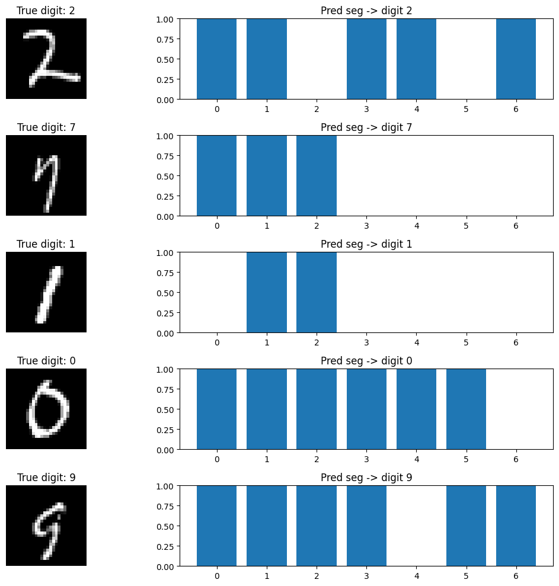

```python
# -----------------------------
# 1. Calculate accuracy from the confusion matrix
# -----------------------------
y_pred_digits = np.array([seg_to_digit(vec) for vec in y_pred_7seg_bin])
cm = confusion_matrix(y_test_mnist, y_pred_digits, labels=[0,1,2,3,4,5,6,7,8,9])
acc_7seg = accuracy_score(y_test_mnist, y_pred_digits)
print("Confusion Matrix:\n", cm)
print("Overall digit classification accuracy (via 7-seg MLP):", acc_7seg)

# -----------------------------
# 2. Display a few test samples and their predicted 7-seg
# -----------------------------

def visualize_7seg_predictions(num_samples=5): # We can change this if needed
    sample_indices = random.sample(range(len(X_test_mnist)), num_samples)
    plt.figure(figsize=(12, 2 * num_samples))
    for i, idx in enumerate(sample_indices):
        img = X_test_mnist[idx].squeeze()  # shape (28,28)
        true_digit = y_test_mnist[idx]
        pred_digit = y_pred_digits[idx]

        plt.subplot(num_samples, 2, 2*i + 1)
        plt.imshow(img, cmap='gray')
        plt.title(f"True digit: {true_digit}")
        plt.axis('off')

        plt.subplot(num_samples, 2, 2*i + 2)
        plt.bar(range(7), y_pred_7seg_bin[idx])
        plt.ylim(0, 1)
        plt.title(f"Pred seg -> digit {pred_digit}")
        plt.xticks(range(7))
    plt.tight_layout()
    plt.show()

visualize_7seg_predictions(5)
```

### Observations:

We achieve 95.3% accuracy in mapping digits to 7-segment codes.

```python
# Install necessary packages
!apt-get install texlive texlive-xetex texlive-latex-extra pandoc
!pip install pypandoc

# Mount Google Drive
from google.colab import drive
drive.mount("/content/drive", force_remount=True)

# Copy the notebook to the current directory
!cp 'drive/My Drive/Colab Notebooks/Assignment1_Group75.ipynb' ./

# Convert the notebook to HTML while keeping the code and output
!jupyter nbconvert --to html "drive/My Drive/Colab Notebooks/Assignment1_Group75.ipynb"

# DEBUG STEPS
!ls 'drive/My Drive/Colab Notebooks/'


# Download the generated HTML
from google.colab import files
files.download('Assignment1_Group75.html')
```

```
Reading package lists... Done
Building dependency tree... Done
Reading state information... Done
pandoc is already the newest version (2.9.2.1-3ubuntu2).
texlive is already the newest version (2021.20220204-1).
texlive-latex-extra is already the newest version (2021.20220204-1).
texlive-xetex is already the newest version (2021.20220204-1).
0 upgraded, 0 newly installed, 0 to remove and 49 not upgraded.
```